# Chess pieces

The package `chessboard` implements different methods for detecting neighbors. All are derived from the [chess game](https://en.wikipedia.org/wiki/Chess#Movement) and allow user to define complex moves to create direct edges (links) between nodes (sampling units). The following table provides a description of the chess pieces available in `chessboard`.

[output not shown]

* These two chess pieces each have two variants: `bishop_left()`, `bishop_right()` and `knight_left()`, `knight_right()`.

In this vignette, we use an extended version (9 transects x 9 quadrats) of the network used in Casajus *et al.* (2023) to illustrate methods for detecting neighbors implemented in `chessboard` and the impact of the different arguments.

## Pawn

> The `pawn` can detect neighbors vertically, i.e. among quadrats along a transect.

The function `pawn()` can be used to detect neighbors (black dots in Fig. 1) of a specific node (red dot in Fig. 1).

```r
pawn(nodes, focus = "5-5", degree = 4, ...)
```

User can change the default settings (Fig. 1A), by adding directionality (`directed = TRUE`, Fig. 1B) and reversing the default directionality (`directed = TRUE` and `reverse = TRUE`, Fig. 1C).

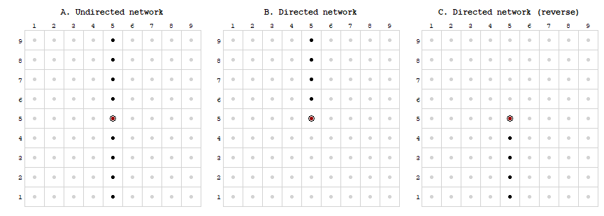

Figure 1. Moves of the **Pawn** (with degree = 4)

Figure 2 shows the connectivity matrix of the 9 x 9 network when neighbors of all nodes are detected by the `pawn` method and with a degree of neighborhood of 4.

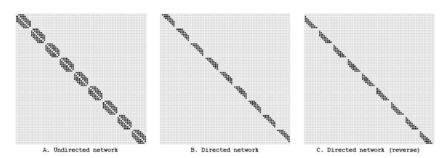

Figure 2. Connectivity matrices of the **Pawn** (with degree = 4)

```r
create_edge_list(nodes, method = "pawn", degree = 4, ...)
```

## Fool

> The `fool` can detect neighbors horizontally, i.e. among transects along a quadrat.

The function `fool()` can be used to detect neighbors (black dots in Fig. 3) of a specific node (red dot in Fig. 3).

```r
fool(nodes, focus = "5-5", degree = 4, ...)
```

User can change the default settings (Fig. 3A), by adding directionality (`directed = TRUE`, Fig. 3B) and reversing the default directionality (`directed = TRUE` and `reverse = TRUE`, Fig. 3C).

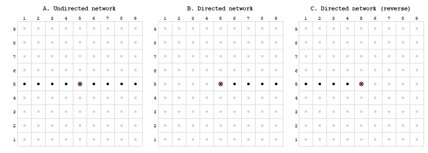

Figure 3. Moves of the **Fool** (with degree = 4)

Figure 4 shows the connectivity matrix of the 9 x 9 network when neighbors of all nodes are detected by the `fool` method and with a degree of neighborhood of 4.

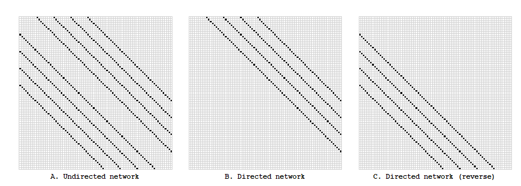

Figure 4. Connectivity matrices of the **Fool** (with degree = 4)

```r
create_edge_list(nodes, method = "fool", degree = 4, ...)
```

## Rook

> The `rook` can detect neighbors both horizontally and vertically, i.e. among transects along a quadrat and among quadrats along a transect.

The function `rook()` can be used to detect neighbors (black dots in Fig. 5) of a specific node (red dot in Fig. 5).

```r
rook(nodes, focus = "5-5", degree = 4, ...)
```

User can change the default settings (Fig. 5A), by adding directionality (`directed = TRUE`, Fig. 5B) and reversing the default directionality (`directed = TRUE` and `reverse = TRUE`, Fig. 5C).

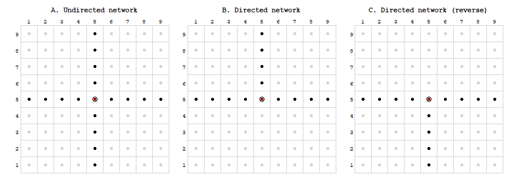

Figure 5. Moves of the **Rook** (with degree = 4)

Figure 6 shows the connectivity matrix of the 9 x 9 network when neighbors of all nodes are detected by the `rook` method and with a degree of neighborhood of 4.

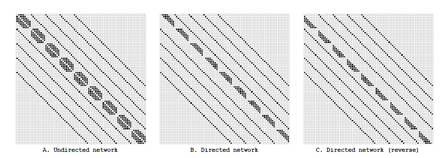

Figure 6. Connectivity matrices of the **Rook** (with degree = 4)

```r
create_edge_list(nodes, method = "rook", degree = 4, ...)
```

## Bishop

> The `bishop` can detect neighbors diagonally.

The function `bishop()` can be used to detect neighbors (black dots in Fig. 7) of a specific node (red dot in Fig. 7).

```r
bishop(nodes, focus = "5-5", degree = 4, ...)
```

User can change the default settings (Fig. 7A), by adding directionality (`directed = TRUE`, Fig. 7B) and reversing the default directionality (`directed = TRUE` and `reverse = TRUE`, Fig. 7C).

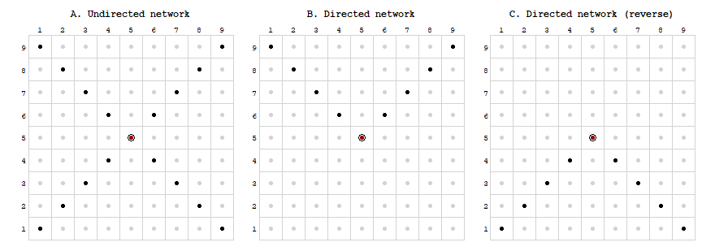

Figure 7. Moves of the **Bishop** (with degree = 4)

Figure 8 shows the connectivity matrix of the 9 x 9 network when neighbors of all nodes are detected by the `bishop` method and with a degree of neighborhood of 4.

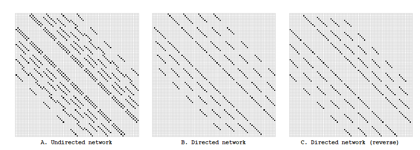

Figure 8. Connectivity matrices of the **Bishop** (with degree = 4)

```r
create_edge_list(nodes, method = "bishop", degree = 4, ...)
```

## Knight

> The `knight` has a complex move, like an ‘L’ shape. It’s the difference between the `wizard` and the `queen`.

The function `knight()` can be used to detect neighbors (black dots in Fig. 9) of a specific node (red dot in Fig. 9).

```r
knight(nodes, focus = "5-5", degree = 4, ...)
```

User can change the default settings (Fig. 9A), by adding directionality (`directed = TRUE`, Fig. 9B) and reversing the default directionality (`directed = TRUE` and `reverse = TRUE`, Fig. 9C).

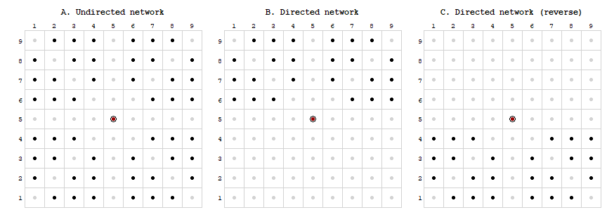

Figure 9. Moves of the **Knight** (with degree = 4)

Figure 10 shows the connectivity matrix of the 9 x 9 network when neighbors of all nodes are detected by the `knight` method and with a degree of neighborhood of 4.

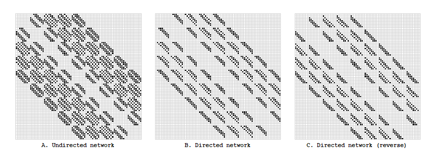

Figure 10. Connectivity matrices of the **Knight** (with degree = 4)

```r
create_edge_list(nodes, method = "knight", degree = 4, ...)
```

## Queen

> The `queen` can detect neighbors horizontally, vertically and diagonally. It’s a combination the `rook` and the `bishop`.

The function `queen()` can be used to detect neighbors (black dots in Fig. 11) of a specific node (red dot in Fig. 11).

```r
queen(nodes, focus = "5-5", degree = 4, ...)
```

User can change the default settings (Fig. 11A), by adding directionality (`directed = TRUE`, Fig. 11B) and reversing the default directionality (`directed = TRUE` and `reverse = TRUE`, Fig. 11C).

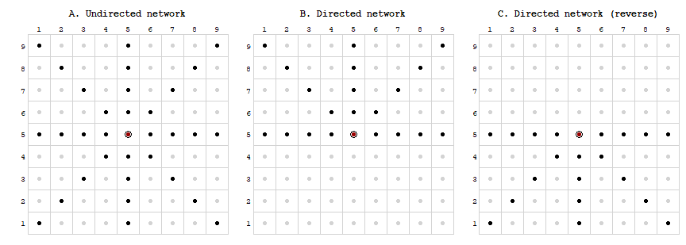

Figure 11. Moves of the **Queen** (with degree = 4)

Figure 12 shows the connectivity matrix of the 9 x 9 network when neighbors of all nodes are detected by the `queen` method and with a degree of neighborhood of 4.

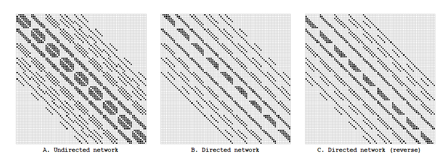

Figure 12. Connectivity matrices of the **Queen** (with degree = 4)

```r
create_edge_list(nodes, method = "queen", degree = 4, ...)
```

## Wizard

> The `wizard` can detect neighbors in any direction. It’s a combination the `queen` and the `knight`.

The function `wizard()` can be used to detect neighbors (black dots in Fig. 13) of a specific node (red dot in Fig. 13).

```r
wizard(nodes, focus = "5-5", degree = 4, ...)
```

User can change the default settings (Fig. 13A), by adding directionality (`directed = TRUE`, Fig. 13B) and reversing the default directionality (`directed = TRUE` and `reverse = TRUE`, Fig. 13C).

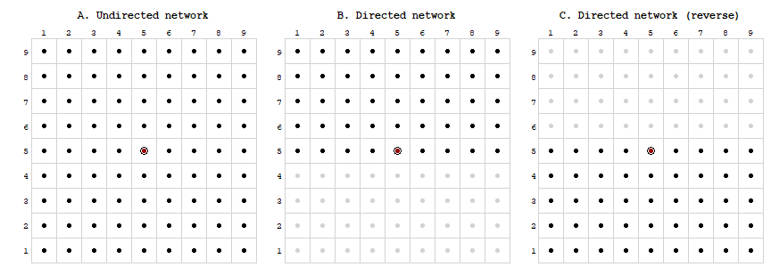

Figure 13. Moves of the **Wizard** (with degree = 4)

Figure 14 shows the connectivity matrix of the 9 x 9 network when neighbors of all nodes are detected by the `wizard` method and with a degree of neighborhood of 4.

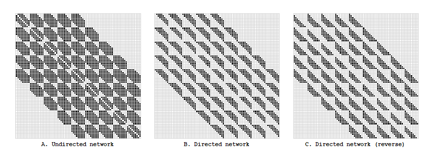

Figure 14. Connectivity matrices of the **Wizard** (with degree = 4)

```r
create_edge_list(nodes, method = "wizard", degree = 4, ...)
```

## Custom moves

It’s possible to create any kind of scenarios by combining the previous moves and by changing the values of the arguments `degree`, `directed`, and `reverse`.

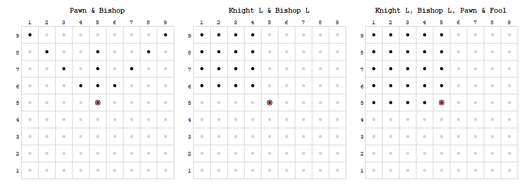

Figure 15. Custom moves

## References

Casajus N, Rievrs Borges E, Tabacchi E, Fried G & Mouquet N (2023) chessboard: An R package for creating network connections based on chess moves. R package version 0.1. URL: https://github.com/frbcesab/chessboard.